# Some experiences on parallel code tuning with MPI+OpenMP

The main goal is to show some configuration options available for OpenMPI (>=3.0) (compiled with GCC 6.4.0) an OpenMP to control the CPUs (virtual or physical cores) where the code will run.

### First code (T1)

The first code (a simple matrices multiplication) is written as:

```python
/** CODE T1 **/
*t = omp_get_wtime();
#pragma omp parallel for private(j,k)
for (i=0; i<N; i++)
{
for (j=0; j<N; j++)
  for (k=0; k<N; k++)
    c1[i*N+j] += a[i*N+k]*b[j*N+k];
}
*t = omp_get_wtime(); t++;
```

Notice that this code can be related to the operation `A*transpose(B)`. This is done in order to assume the second multiple (b) to be aligned in memmory. In fact, these variables are declared as:

```python
//memmory alignment: in runtime, a,b,c1 will be aligned in chunks of 64 bits (minimum)
double *a  = (double*)_mm_malloc(sizeof(double)*N*N,64);
double *b  = (double*)_mm_malloc(sizeof(double)*N*N,64);
double *c1 = (double*)_mm_malloc(sizeof(double)*N*N,64);
```

and initialized to:

```python
/** CODE T0 **/
for (i=0; i<N*N; i++)
{
    a[i] = sin((double)(i%20));
    b[i] = cos((double)(i%20));
    c1[i] = 0.;
    c2[i] = 0.;
}
```

### Second code (T2)

Taken from [here](https://people.freebsd.org/~lstewart/articles/cpumemory.pdf) (see section 6.2.1 and Appendix A.1), the second code (AVX-vectorized matrices multiplication) is written as:

```python
/** CODE T2 **/
#define SM (CLS / sizeof (double))
double *rres;
double *rmul1;
double *rmul2;

*t = omp_get_wtime();
#pragma omp parallel for private(j,k,i2,j2,k2)
for (i = 0; i < N; i += SM)
    for (j = 0; j < N; j += SM)
      for (k = 0; k < N; k += SM)
        for (i2 = 0, rres = &c2[i*N+j], rmul1 = &a[i*N+k]; i2 < SM;
             ++i2, rres += N, rmul1 += N)
        {
          _mm_prefetch (&a[8], _MM_HINT_NTA);
          for (k2 = 0, rmul2 = &b[k*N+j]; k2 < SM; ++k2, rmul2 += N)
          {
            __m128d m1d = _mm_load_sd (&rmul1[k2]);
            m1d = _mm_unpacklo_pd (m1d, m1d);
            for (j2 = 0; j2 < SM; j2 += 2)
            {
              __m128d m2 = _mm_load_pd (&rmul2[j2]);
              __m128d r2 = _mm_load_pd (&rres[j2]);
              _mm_store_pd (&rres[j2],
              _mm_add_pd (_mm_mul_pd (m2, m1d), r2));
            }
          }
        }
*t = omp_get_wtime() - *t; t++:
```

### A simple run

Here show the basic tools used for the analysis performed in this document. First, one is able to create a mapping processor_number to core_id. When Hyper-Threading is active, two different processors number are mapped into a single core id. In the current context, a physical core can be labeled by two parameters `(physical id, core id)`, which can be obtained from the file /proc/cpuinfo. Doing so it is obtained a mapping like:

| physical id = 0 |  | physical id = 1 |  | physical id = 0 |  | physical id = 1 |  |
| --- | --- | --- | --- | --- | --- | --- | --- |
| processor | core id | processor | core id | processor | core id | processor | core id |
| 0,28 | 0 | 14,42 | 0 | 7,35 | 8 | 21,49 | 8 |
| 1,29 | 1 | 15,43 | 1 | 8,36 | 9 | 22,50 | 9 |
| 2,30 | 2 | 16,44 | 2 | 9,37 | 10 | 23,51 | 10 |
| 3,31 | 3 | 17,45 | 3 | 10,38 | 11 | 24,52 | 11 |
| 4,32 | 4 | 18,46 | 4 | 11,39 | 12 | 25,53 | 12 |
| 5,33 | 5 | 19,47 | 5 | 12,40 | 13 | 26,54 | 13 |
| 6,34 | 6 | 20,48 | 6 | 13,41 | 14 | 27,55 | 14 |

For example, if our program runs 4 threads, setting them to run on the processors 0 to 3 will allow them to run on 4 different physical cores. While setting them to run on the processors 0, 28, 1 and 29, will force them to run on two physical cores (two threads each).

### The GOMP_CPU_AFFINITY variable

Running a code parallelized with MPI/OpenMP without configuring the threads distribution will make the OS and the process manager (Slurm, PBS, etc) to take care of it. One option available for the user to set this configuration the the environment varible [GOMP_CPU_AFFINITY](https://gcc.gnu.org/onlinedocs/libgomp/GOMP_005fCPU_005fAFFINITY.html)). It allows to bind the different threads of a program compiled with the OpenMP library.

### Example: 28 threads running on physical/virtual cores

The next results in computational times correspond to the average of 10 run samples. Setting

```
$ export OMP_NUM_THREADS=28
```

and doing

```
$ export GOMP_CPU_AFFINITY="0-27"
$ ./example 3024
```

returns

```
T0 0.035 T1 1.683 T2 0.442
```

while

```
$ export GOMP_CPU_AFFINITY="0-13 28-41"
$ ./example 3024
```

returns

```
T0 0.056 T1 1.582 T2 0.631
```

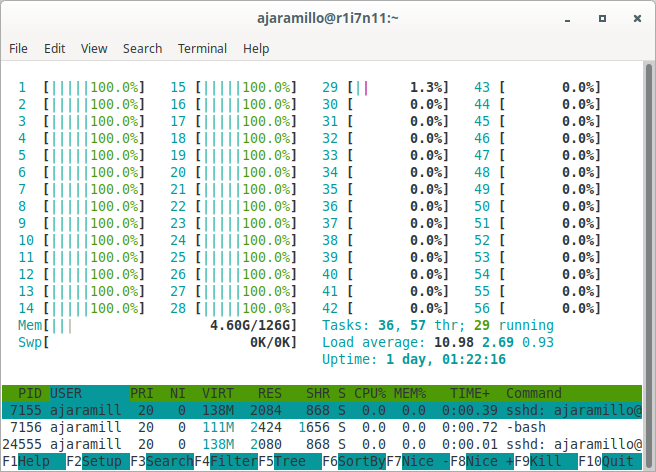

while during the second run:

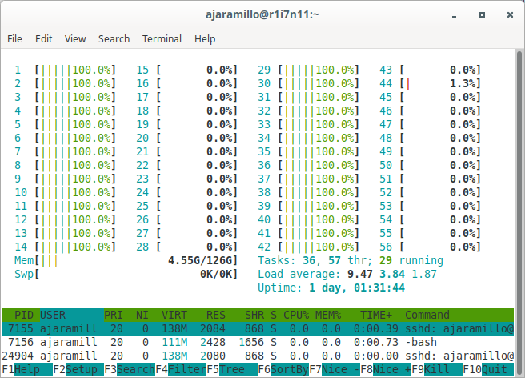

### Pure MPI tests

Using a single core (`export OMP_NUM_THREADS=1`), the computational time corresponds to

```
T0 0.444 T1 30.879 T2 12.384
```

Now, these previous results are reproduced when using only MPI parallelization. This is emulated by reducing the number of columns of the second multiple from 3024 to 3024/28 = 108. Notice that this way one is assuming no communication is needed of the computations made at each process to the master. For this one unset the variable `GOMP_CPU_AFFINITY` by doing

```
$ unset GOMP_CPU_AFFINITY
```

calling the code by

```
$ mpirun -n 28 -map-by socket -use-hwthread-cpus ./example 3024 108
```

returns

```
T0 0.368 T1 1.179 T2 0.481
```

which means a speed-up of ~26 for both codes. In this run, by setting `-map-by socket` OpenMPI *spreads* to processes along all the available sockets (two in this case) and with `-use-hwthread-cpus` it is indicated to use only physical cores. One can also test the case where only 14 physical cores are used (+14 virtual). For this one can indicate to MPI the list of cores to by used by the argument `--cpu-set` as:

```
$ mpirun --cpu-set 0-13 -n 28 ./example 3024 108
```

```
T0 0.397 T1 1.312 T2 0.965
```

Altough the argument `--cpu-set` did the work, the arguments `-map-by socket` and `-use-hwthread-cpus` since they are more flexible when treating with modern systems (with several nodes, sockets per node, cores per socket, threads per core). Next we present examples of a code parallelized with MPI+OpenMP. The complete code used for the previous examples can be bound [here](https://alfredojaramillo.github.io/example.c).

## MPI+OpenMP

### Case: explicit discretization of a transport equation

The code used in this section corresponds to the numerical solution of a Hyperbolic PDE arising in simulations of Flow in Porous Media, the Buckley-Leverett equation. In these cases the pressure variable has been fixed so the convective field depends only on the saturation variable. Without entering in the details of the implementation, the main FLOP-intensive loop to be parallelized is

```python
#pragma omp parallel for private(i,j,is,isvel)
for(k = NCAPS; k<Nz+NCAPS; k++)
{
  for(j = NCAPS; j<Ny+NCAPS; j++)
  {
    isvel = PINDEX(0,j-NCAPS,k-NCAPS,Nx,Ny);

    is = PINDEX(NCAPS,j,k,Nx+2*NCAPS,Ny+2*NCAPS);

    double *_sd = &(satn[PINDEX(NCAPS,j-1,k,Nx+2*NCAPS,Ny+2*NCAPS)]);
    double *_su = &(satn[PINDEX(NCAPS,j+1,k,Nx+2*NCAPS,Ny+2*NCAPS)]);
    double *_sb = &(satn[PINDEX(NCAPS,j,k-1,Nx+2*NCAPS,Ny+2*NCAPS)]);
    double *_st = &(satn[PINDEX(NCAPS,j,k+1,Nx+2*NCAPS,Ny+2*NCAPS)]);

    double *_satnp = &(Transp->saturation[PINDEX(NCAPS,j,k,Nx+2*NCAPS,Ny+2*NCAPS)]);

    double *_vr = &(v->r[isvel]); double *_vl = &(v->l[isvel]);
    double *_vu = &(v->u[isvel]); double *_vd = &(v->d[isvel]);
    double *_vt = &(v->t[isvel]); double *_vb = &(v->b[isvel]);

    double *_sourceMASK = &(Darcy->sourceMASK[isvel]);

    // INNER-MOST LOOP IS VECTORIZED
    #pragma omp simd // this pragma is considered by the compiler regardless the number of threads
    for(i = NCAPS; i<Nx+NCAPS; i++)
    {
      double sr = (*_vr>0.)? satn[is] : satn[is+1];  double sl = (*_vl>0.)? satn[is] : satn[is-1];
      double su = (*_vu>0.)? satn[is] : (*_su);      double sd = (*_vd>0.)? satn[is] : (*_sd);
      double st = (*_vt>0.)? satn[is] : (*_st);      double sb = (*_vb>0.)? satn[is] : (*_sb);

      // BALANCE EQUATION
      *_satnp = satn[is]

        - (dt/hx)*(*_vr*FRAC(sr) + *_vl*FRAC(sl)) - (dt/hy)*(*_vu*FRAC(su) + *_vd*FRAC(sd)) - (dt/hz)*(*_vt*FRAC(st) + *_vb*FRAC(sb))

        //ADDING THE NUMERICAL DIVERGENCE WHENEVER THE SOURCES ARE NULL (MARKED AS *_sourceMASK = 1.0)
        + *_sourceMASK * dt*FRAC(satn[is])*( (1./hx)*(*_vr+*_vl) + (1./hy)*(*_vu+*_vd) + (1./hz)*(*_vt+*_vb) );

      is++;
      _sd++; _su++; _sb++; _st++; _satnp++;

      _vr++; _vl++; _vu++; _vd++; _vt++; _vb++;

      _sourceMASK++;
    }
  }
}
```

The code is written along the MPI paradigm, the computational domain is divided into subdomains and each MPI process has the information needed to compute the loop above in some its associated subdomain. This loop is inside a time-loop and at each time-step it is necessary to comunicate the results of the transported quantity between shared boundaries (using `MPI_Isend`, `MPI_Irecv`, etc).

The computational times presented in this section correspond to 50 time-iterations (or 50 avaliations of the loop above) for each configuration tested. First, let us set one million cells per subdomain (so `Nx*Ny*Nz=1e6`) and use only 1 process and setting `OMP_NUM_THREADS=1`, the computational time for such configuration is of 22.8 s (which can be computed to correspond to 4.4 GFLOPS). Whereas doing

[output not shown]

```
$ export OMP_NUM_THREADS=28
$ export GOMP_CPU_AFFINITY="0-13 28-41"
$ mpirun -n 1 ../../build/linux_gcc/partrans_linux_gcc_opt
```

the computational time drops to 7.4 s, a speed-up of 3. And with (28 physical)

```
$ export OMP_NUM_THREADS=28
$ export GOMP_CPU_AFFINITY="0-27"
$ mpirun -n 1 ../../build/linux_gcc/partrans_linux_gcc_opt
```

the computational time slightly aguments to 7.6 s. Now, it is possible to set the number of MPI processes to 14 and set `OMP_NUM_THREADS=2`, thus each MPI process will *use* two-threads. Even more, one can try to take profit of the Hyper-Threading technology by setting `OMP_NUM_THREADS=4`. From the options tested, the best one was to use the two arguments `-map-by socket -use-hwthread-cpus`, giving a computatioal time of ~1.73 s (averaged over 10 samples). In the system where these tests were performed, the variable `GOMP_CPU_AFFINITY` seems to not be compatible with this kind of mixture MPI+OpenMP, making the code to run on only one core, so the next command was necessary

```
$ unset GOMP_CPU_AFFINITY
```

Also, no relevant difference on the computational times was found when setting `OMP_NUM_THREADS=4` (average time of 1.78 s), which indecates that for these cases Hyper-Threading gave no gain.

### Case: solving several linear problems with MUMPS

This case is inspired from the discretization of an elliptic PDE by means of a [multiscale method](https://doi.org/10.1016/j.jcp.2017.11.002). A series of linear are needed to be solved, reading:

\begin{equation} A^{i,j} X^{i,j} = B^{i,j},\qquad i=1\ldots N_d, j=1\ldots N_p \end{equation}

The matrices $A^{i,j}$ are of order $N$, symmetric, sparse and share the same sparsity pattern. Each unknown $X^{i,j}$ and the r.h.s. $B^{i,j}$ is a matrix of $M$ columns, with $M\geq 12$. The distribution of these problems along the physical cores of the machines is as follows: fixing some index $j\in\{1\ldots N_p\}$, a single core will compute the solution of $A^{i,j} X^{i,j} = B^{i,j}$ for every $i\in\{1\ldots N_d\}$, and it is assumed that $p$ is equal to the number of physical cores available in the system.

For each pair $(i,j)$, $X^{i,j}$ is computed using the [MUMPS library](https://github.com/group-gu/mumps). This solution is made in three phases:

1. Analysis (ANA): among other things, some library is called to compute a reordering of the unkwnowns (here we use PORD).
2. Factorization (FAC): it is computed a Cholesky factorization of $A^{i,j}$.
3. Backward Substitution (BAS): $X^{i,j}$ is computed using the factorization of step 2.

The number of MPI processes is equal to $p$ (the number of physical cores), and each rank allocates $N_d$ MUMPS structures together with the arrays needed for the corresponding matrices. After that, three loops perform the three phases described above. This is written as:

```python
tstart = MPI_Wtime();
#pragma omp parallel for private(i,_id)
for(i=0; i < Nd; i++)
{
    _id = &id[i]; // each id[i] is a MUMPS structure

    (*_id).job = PHASE;
    dmumps_c(_id); // MUMPS call
}
times.backward = MPI_Wtime() - tstart;
```

where `PHASE` is equal to 1 (analysis), 2 (factorization) or 3 (backward substitution).